# IODS course project

Sanni Variskallio

# Introduction to Open Data Science - Course Project

# About the project

Introduction to open data science course 2023.

Link to my GitHub repository https://github.com/julivaris/IODS-project

# Feelings etc.

Feeling good. I expect to learn to use git version control system and R better in data science framework. I found the course from Sisu. R for Health Data Science seems to be clear and user-friendly introduction to R. My favourite topic is probably the tuning plots, chapter 5. I expect the most difficult topics to relate regression models and tests that require some statistical understanding. Starting with R Markdown from the start is a good idea.

```r
date()
```

```
## [1] "Sun Nov 12 22:24:56 2023"
```

# Week 2

*This week’s exercises were about data wrangling and performing* *and interpreting a simple linear regression*

```r
date()
```

```
## [1] "Sun Nov 12 22:24:56 2023"
```

Read in the students2014 data

```r
learning14 <- read.csv("https://raw.githubusercontent.com/KimmoVehkalahti/Helsinki-Open-Data-Science/master/datasets/learning2014.txt", header = TRUE, sep = ",")
```

```r
str(learning14)
```

```
## 'data.frame':    166 obs. of  7 variables:
##  $ gender  : chr  "F" "M" "F" "M" ...
##  $ age     : int  53 55 49 53 49 38 50 37 37 42 ...
##  $ attitude: num  3.7 3.1 2.5 3.5 3.7 3.8 3.5 2.9 3.8 2.1 ...
##  $ deep    : num  3.58 2.92 3.5 3.5 3.67 ...
##  $ stra    : num  3.38 2.75 3.62 3.12 3.62 ...
##  $ surf    : num  2.58 3.17 2.25 2.25 2.83 ...
##  $ points  : int  25 12 24 10 22 21 21 31 24 26 ...
```

```r
learning14$gender <- as.factor(learning14$gender)
summary(learning14)
```

```
##  gender       age           attitude          deep            stra
##  F:110   Min.   :17.00   Min.   :1.400   Min.   :1.583   Min.   :1.250
##  M: 56   1st Qu.:21.00   1st Qu.:2.600   1st Qu.:3.333   1st Qu.:2.625
##          Median :22.00   Median :3.200   Median :3.667   Median :3.188
##          Mean   :25.51   Mean   :3.143   Mean   :3.680   Mean   :3.121
##          3rd Qu.:27.00   3rd Qu.:3.700   3rd Qu.:4.083   3rd Qu.:3.625
##          Max.   :55.00   Max.   :5.000   Max.   :4.917   Max.   :5.000
##       surf           points
##  Min.   :1.583   Min.   : 7.00
##  1st Qu.:2.417   1st Qu.:19.00
##  Median :2.833   Median :23.00
##  Mean   :2.787   Mean   :22.72
##  3rd Qu.:3.167   3rd Qu.:27.75
##  Max.   :4.333   Max.   :33.00
```

Information on the variables is available from https://www.mv.helsinki.fi/home/kvehkala/JYTmooc/JYTOPKYS2-meta.txt.

Short description

Age: Age (in years) derived from the date of birth

Gender: Male = 1 Female = 2

Attitude: Global attitude toward statistic

Deep: Deep approach

Surf: Surface approach

Stra: Strategic approach

Points: Exam points

It seems that majority of students are female (wondering whether non-binary was an option…), they are aged 17-55, and they have received exam points between 7 and 33 (mean 22.7) from Introduction to Social Statistics course in fall 2014.

```r
library(reshape2)
#Convert wide to long
l14.melt <- melt(learning14)  # gender as id
head(l14.melt)
```

```
##   gender variable value
## 1      F      age    53
## 2      M      age    55
## 3      F      age    49
## 4      M      age    53
## 5      M      age    49
## 6      F      age    38
```

# Graphical overview

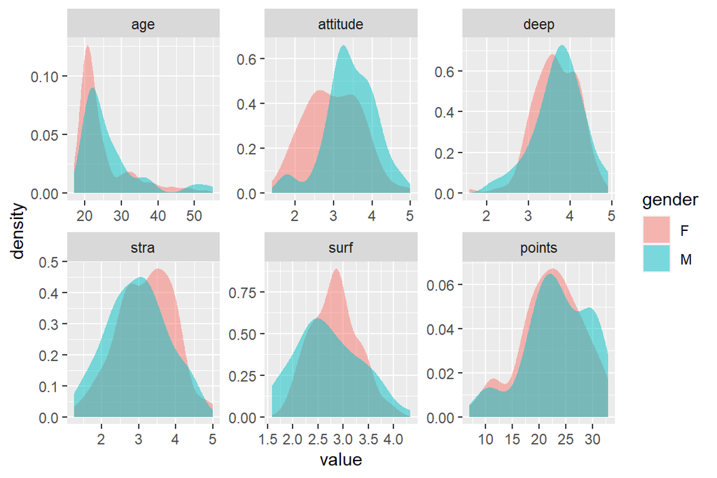

```r
library(ggplot2)
ggplot(data = l14.melt, aes(x = value, fill = gender)) +
  stat_density(alpha = 0.5, position = "identity") + facet_wrap(~variable, scales = "free")
```

Plot count histograms as comparison (to see if we have enough data for smoothing distribution plots as done above). (Non-stacking and alpha to see through.)

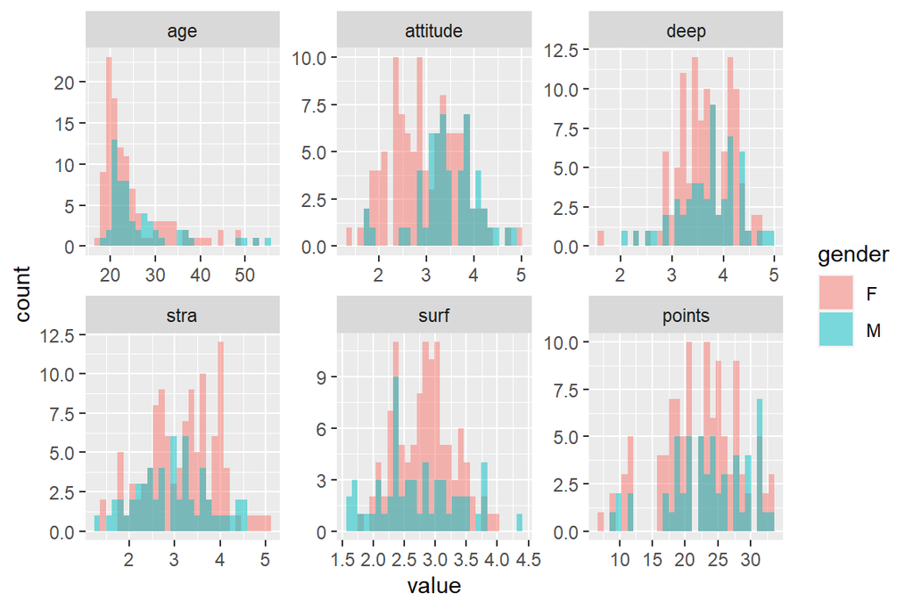

```r
ggplot(data = l14.melt, aes(x = value, fill = gender)) +
        geom_histogram(aes(y = ..count..), position = "identity", alpha = 0.5) + facet_wrap(~variable, scales = "free")
```

Some findings based on above graphs:

- the age distribution is skewed towards younger, most students are in their early 20s
- female students have lower attitude points compared to male students
- female students have somewhat higher points in strategic approach (stra)

### Correlations

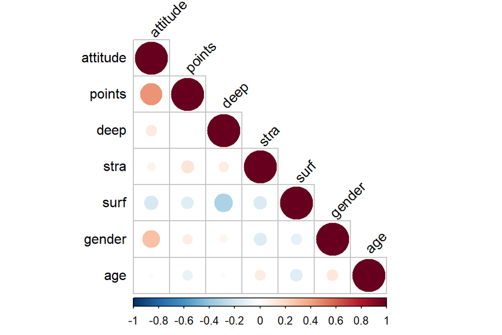

```
## $r
##          attitude points  deep  stra  surf gender age
## attitude        1
## points       0.44      1
## deep         0.11  -0.01     1
## stra        0.062   0.15 0.097     1
## surf        -0.18  -0.14 -0.32 -0.16     1
## gender       0.29  0.093 0.058 -0.15 -0.11      1
## age         0.022 -0.093 0.025   0.1 -0.14   0.12   1
##
## $p
##          attitude points    deep  stra  surf gender age
## attitude        0
## points    4.1e-09      0
## deep         0.16    0.9       0
## stra         0.43   0.06    0.22     0
## surf        0.024  0.064 2.1e-05 0.038     0
## gender    0.00012   0.23    0.46 0.061  0.15      0
## age          0.78   0.23    0.75  0.19 0.069   0.13   0
##
## $sym
##          attitude points deep stra surf gender age
## attitude 1
## points   .        1
## deep                     1
## stra                          1
## surf                     .         1
## gender                                  1
## age                                            1
## attr(,"legend")
## [1] 0 ' ' 0.3 '.' 0.6 ',' 0.8 '+' 0.9 '*' 0.95 'B' 1
```

```r
#install.packages('corrplot')
library(corrplot)
library(RColorBrewer)
newdata <- learning14
newdata$gender <- as.numeric(newdata$gender)
#M <-cor(newdata)
#corrplot(M, type="upper", order="hclust",
#         col=brewer.pal(n=8, name="RdYlBu"))

source("http://www.sthda.com/upload/rquery_cormat.r")
rquery.cormat(newdata)
```

The strongest positive correlation is between exam points and attitude. Gender also seems to be correlated with attitude. The strongest negative correlation is between deep and surface approaches.

# Linear regression

Let’s fit a linear model with age, gender and attitude es explanatory variables and exam points as an outcome

```r
model1 <- lm(points~ age + gender + attitude, data = learning14)
summary(model1)
```

```
##
## Call:
## lm(formula = points ~ age + gender + attitude, data = learning14)
##
## Residuals:
##      Min       1Q   Median       3Q      Max
## -17.4590  -3.3221   0.2186   4.0247  10.4632
##
## Coefficients:
##             Estimate Std. Error t value Pr(>|t|)
## (Intercept) 13.42910    2.29043   5.863 2.48e-08 ***
## age         -0.07586    0.05367  -1.414    0.159
## genderM     -0.33054    0.91934  -0.360    0.720
## attitude     3.60657    0.59322   6.080 8.34e-09 ***
## ---
## Signif. codes:  0 '***' 0.001 '**' 0.01 '*' 0.05 '.' 0.1 ' ' 1
##
## Residual standard error: 5.315 on 162 degrees of freedom
## Multiple R-squared:  0.2018, Adjusted R-squared:  0.187
## F-statistic: 13.65 on 3 and 162 DF,  p-value: 5.536e-08
```

## Interpretation

Multiple R-squared of the model with all three explanatory variables is 0.2018 which means that about 20% of the variation in exam points can be explained by the three variables.

## Model diagnostics

Testing assumptions of linear model.

### Residuals vs fitted values

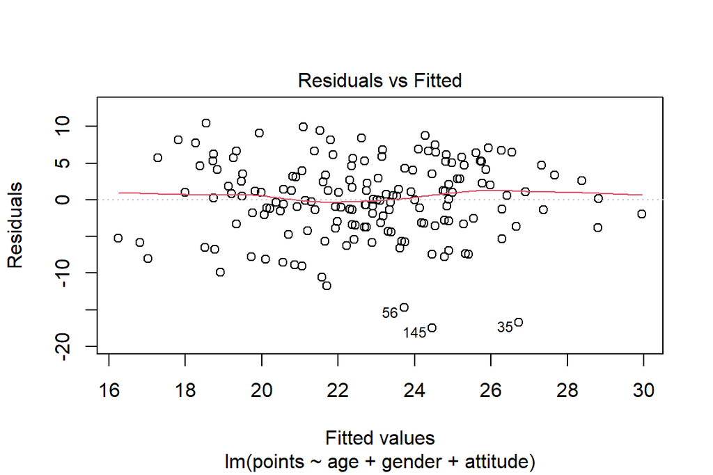

```r
plot(model1, 1)
```

There seems not to be a pattern in the red line, suggesting it is safe to assume linear relationship between the explanatory variables and exam points outcome.

### Normality of residuals

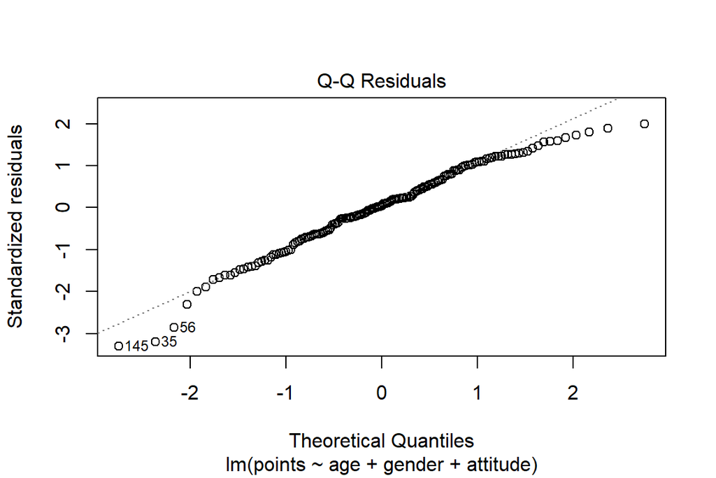

```r
plot(model1, 2)
```

Based on QQ-plot there seems not be any strong violation to the normality assumption as there is no clear pattern.

### Residuals vs Leverage

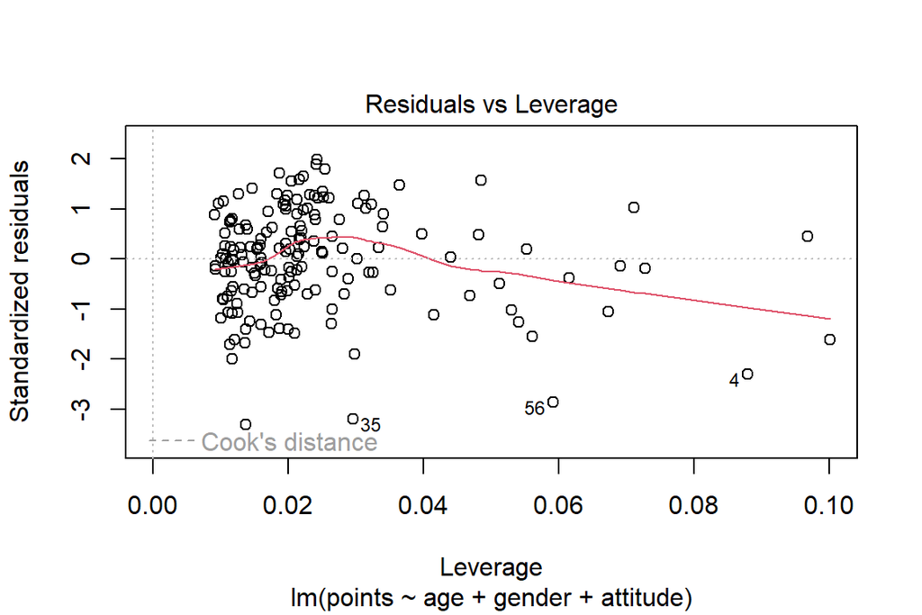

```r
plot(model1, 5)
```

Residuals vs leverage plot shows three outliers, these could be explored further.

(more chapters to be added similarly as we proceed with the course!)